# Demographics, Social Media Engagement, and Cancer Beliefs: Comparing Telehealth Users and Non-Users

Author

Songyi Ahn, Nakyung Lee, Nishat Parvez

## Abstract

This study investigates the factors influencing telehealth adoption and discusses its implications for equitable healthcare delivery. Using data from the Health Information National Trends Survey 6 (HINTS6), conducted by the National Cancer Institute, the research descriptively analyzed demographic and socio-economic characteristics, social media usage and engagement, and cancer risk perception of telehealth users and non-users. The findings reveal that there are barriers or possibly limited access to telehealth among certain populations, alongside facilitators like frequent online health engagement. The results highlight the need for targeted strategies to bridge digital divides and promote equitable access to telehealth services across diverse demographic groups.

**Keywords**: telehealth, healthcare disparities, social media, cancer risk perception, health behavior analysis.

## Introduction

The increasing adoption of telehealth services has transformed healthcare delivery by offering more accessible and convenient solutions for diverse health needs (Weinstein et al. 2014). However, ensuring equitable access to these services requires a deeper understanding of the characteristics that influence their utilization. This study focuses on identifying and analyzing demographic, socio-economic, and behavioral factors that differentiate telehealth users from non-users with an exploratory object regarding this matter. By examining these factors, the study seeks to provide rudimentary insights into how telehealth can better serve diverse populations.

This research addresses three key areas by leveraging the Health Information National Trends Survey 6 data (HINTS6) from the National Cancer Institute (2022). First, it examines demographic and socio-economic factors to uncover patterns in telehealth usage and potential disparities in digital health engagement because individual characteristics could serve as barriers or facilitators for telehealth access (Rani, Hafeez-Baig, and Gururajan 2019). Second, it explores social media usage patterns and engagement levels with health information, comparing telehealth users and non-users. Given the growing role of social media as a source of health information (Zhao and Zhang 2017), social media usage and activities regarding health information could be some meaningful factors in understanding people’s willingness to adopt digital healthcare services. Finally, the study investigates cancer risk perception among telehealth users and non-users to analyze how health awareness is related to telehealth usage. Since telehealth can be an effective tool for health care or education (Garber and Gustin 2022), grasping how people perceive their cancer risk could help tailor telehealth services to meet the needs of different groups of people. By integrating these dimensions, the research could contribute to a deeper understanding of telehealth adoption and their role in enhancing digital health equity for public health.

## Research Questions

- *RQ1: How do demographic and socio-economic factors differ between telehealth users and non-users?*
- *RQ2: How do social media usage frequency and health information engagement levels on social media differ between telehealth users and non-users?*
- *RQ3: How do cancer-related risk perceptions differ between telehealth users and non-users?*

## Methods

### Overall Methods

To answer the research questions, this study utilized data from the Health Information National Trends Survey 6 (HINTS 6), conducted by the National Cancer Institute between March 7, 2022 and November 8, 2022 (National Cancer Institute 2024). The HINTS 6 dataset captures the American public’s knowledge, attitudes, and behaviors related to various health topics (National Cancer Institute 2024). For this study, we focused on sectors including telehealth usage, demographics, social media usage and engagement, and cancer-related beliefs. The publicly available HINTS 6 for R dataset, accessible on the HINTS website, was used for analysis. The original data were collected using a mailing approach, where participants received both a web survey link and a paper survey (National Cancer Institute 2024). The sampling method followed a stratified design based on U.S. addresses, categorized into four strata: high/low minority population and rural/urban areas (National Cancer Institute 2024). All households received $2 for their participation (National Cancer Institute 2024). The total number of participants in the HINTS6 survey was 6,252. However, the sample size for each research question varied, as missing responses were excluded from the analyses relevant to each research question. Detailed methods for each question are discussed below.

### Methods for RQ1

The RQ1 was examined using a structured data preparation and analysis approach based on HINTS survey data. This involved selecting relevant variables, including telehealth usage, age, gender, ethnicity, education, and household income. These variables provided a robust framework for analyzing patterns and disparities in telehealth adoption.

Unnecessary columns were dropped, and rows containing missing data were omitted to ensure a clean and complete dataset. The pivot_longer function transformed the dataset into a long format, enabling targeted filtering and ensuring no missing values in the analysis. Subsequently, the dataset was reshaped to its original structure using pivot_wider for consistency in interpretation.

Visualizations were created for each demographic variable using the *ggplot2* package, providing insights into telehealth usage patterns by age, gender, education, income, and ethnicity. Summary statistics, such as means and medians, were computed to further describe the differences between telehealth users and non-users. This comprehensive approach facilitated an in-depth understanding of the demographic and socio-economic disparities in telehealth adoption, contributing to efforts to enhance equity in digital healthcare solutions.

### Methods for RQ2

For RQ2, the original HINTS survey questionnaires on telehealth usage, social media frequency, and health information engagement on social media were utilized. All missing responses were excluded for the analysis.

In the HINTS data, telehealth usage was measured with the question: “In the past 12 months, did you receive care from a doctor or health professional using telehealth?” Participants had four response options: (1) Yes, by video, (2) Yes, by phone call, (3) Yes, some by video and some by phone call, and (4) No telehealth visits in the past 12 months. For this study, the three ‘Yes’ options were grouped as the ‘Yes’ category, while option (4) was categorized as the ‘No’ group.

Social media usage frequency was measured with the question: “In the last 12 months, how often did you visit a social media site?” Participants chose one from five options: (1) Almost every day, (2) At least once a week, (3) A few times a month, (4) Less than once a month, and (5) Never. These were recoded into 5-point Likert scale, where ‘Never’ was 1, ‘Less than once a month’ was 2, ‘A few times a month’ was 3, ‘At least once a week’ was 4, ‘Almost every day’ was 5.

There were three questionnaires asking about health information engagement on social media. The first asked about sharing behavior, specifically, “In the last 12 months, how often did you share personal health information on social media?” The second question focused on interacting behavior with the question, “In the last 12 months, how often did you interact with people who have similar health or medical issues on social media or online forums?” The third question addressed watching behavior, asking, “In the last 12 months, how often did you watch a health-related video on a social media site?” Applying the same recoding approach as for social media usage frequency, responses, ranging from ‘Never’ to ‘Almost every day,’ were recoded into a 5-point Likert scale. The average score for each participant was calculated from the three items. Participants with an average score in the upper one-third of the distribution had a score of 1.00 or lower, while those in the upper two-thirds had a score of 1.67 or lower, with the maximum possible average score being 5. Using these relative thresholds, participants were categorized into three engagement groups: the Low group, with an average score of 1.00 or lower; the Medium group, with an average score greater than 1.00 but not exceeding 1.67; and the High group, which included all remaining participants with higher scores.

### Methods for RQ3

For RQ3, the original HINTS survey questionnaires on telehealth usage, cancer screening and awareness, and beliefs about cancer were selected. Similar to RQ2, telehealth usage was based on responses to a survey question asking whether the participant had received care from a doctor or health professional through telehealth in the past year. After recoding the answers either “yes” or “no”, and excluding all missing responses, the results were used in the analysis.

Cancer risk perception was measured by averaging responses to a questionnaire that asked about the participant’s interest in receiving cancer screenings in the coming year (“How interested are you in having a cancer screening test in the next year?”), their fear of developing cancer (“How worried are you about getting cancer?”), how susceptible they felt to cancer (“Compared to other people your age, how likely do you think you are to get cancer in your lifetime?”), their belief in the prevalence of cancer-causing factors (“How much do you agree or disagree that it seems like everything causes cancer?”), and their opinion on the effectiveness of cancer prevention activities (“How much do you agree or disagree that there’s not much you can do to lower your changes of getting cancer?”). Responses to these questions were converted into a 5-point Likert scale, where lower scores represented lower cancer risk perception, and higher scores represented higher cancer risk perception. Based on the average score, individuals were classified into three groups: those in the lowest third of scores were categorized as “low level,” those in the middle third as “medium level,” and the remaining individuals as “high level.”

For this project, program R created by R Core Team (2024) was used for data analysis. Then R packages such as tidyverse (Wickham et al. 2019), here (Müller 2020), and rio (Chan et al. 2023) were applied.

## Result

### Demographic Factors and Telehealth

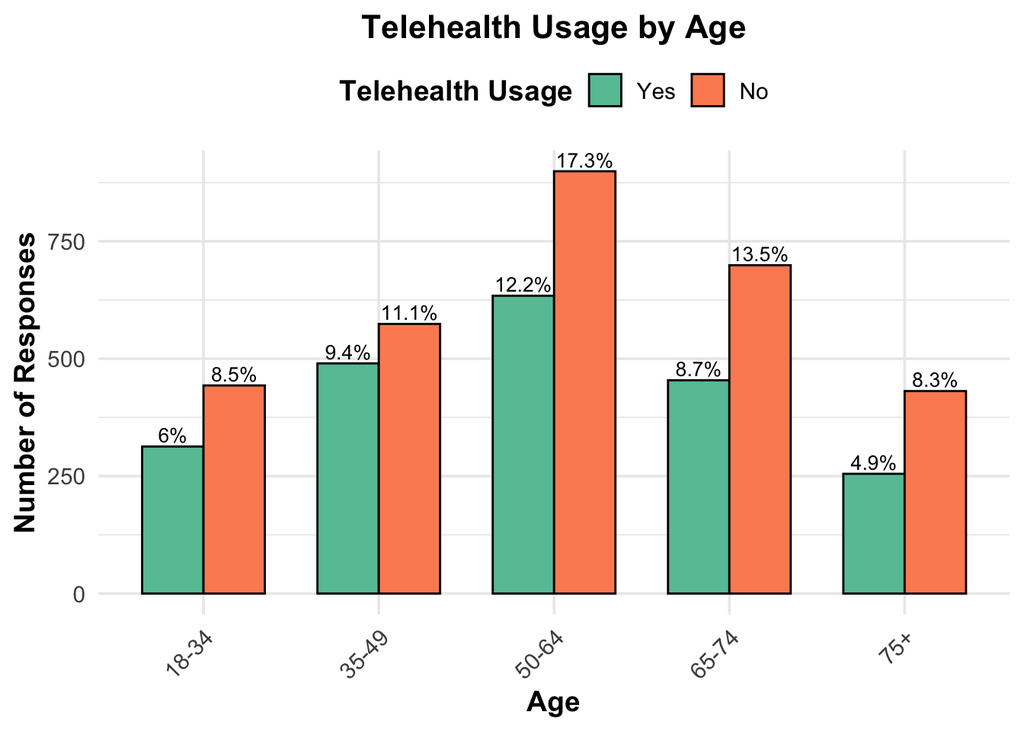

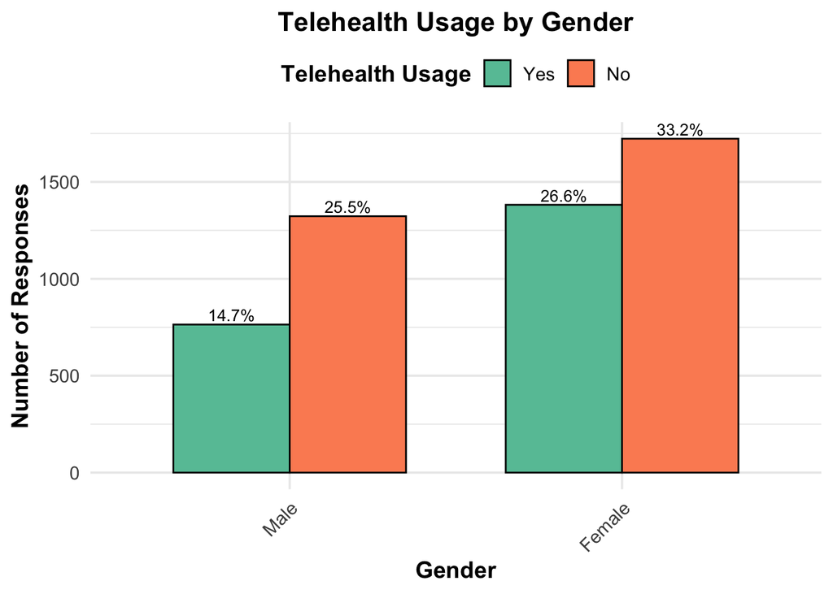

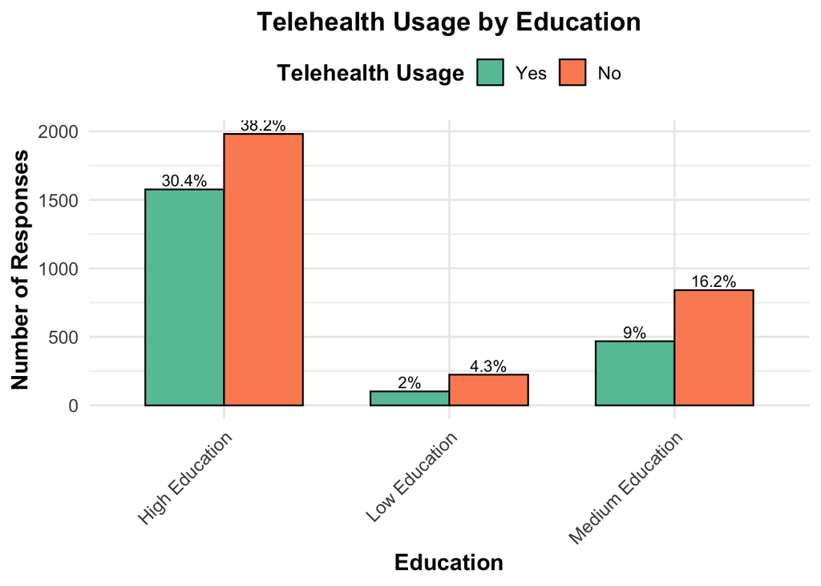

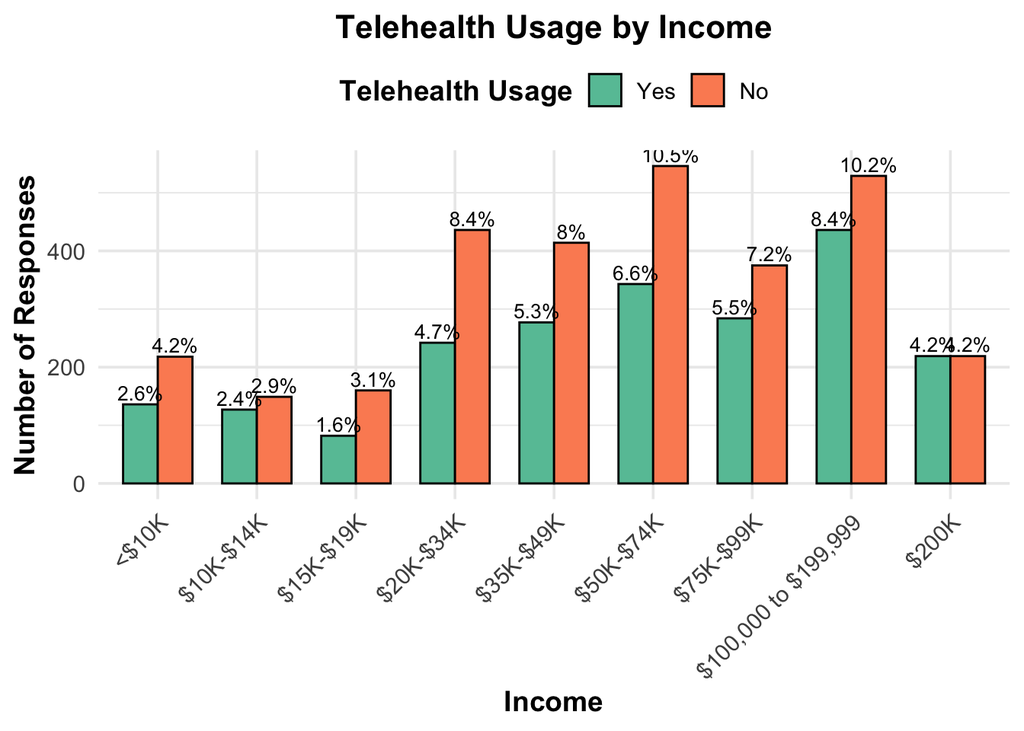

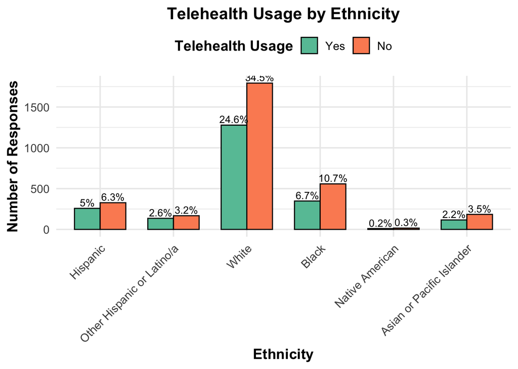

Summary Statistics for Telehealth Usage with Gender and Demographics

| Telehealth | Telehealth Statistics Age_mean | Telehealth Statistics Age_median | Telehealth Statistics Age_sd | Telehealth Statistics Gender_mean | Telehealth Statistics Gender_median | Telehealth Statistics Gender_sd | Telehealth Statistics Education_mean | Telehealth Statistics Education_median | Telehealth Statistics Education_sd | Telehealth Statistics Income_mean | Telehealth Statistics Income_median | Telehealth Statistics Income_sd | Telehealth Statistics Ethnicity_mean | Telehealth Statistics Ethnicity_median | Telehealth Statistics Ethnicity_sd | Telehealth Statistics count |
| --- | --- | --- | --- | --- | --- | --- | --- | --- | --- | --- | --- | --- | --- | --- | --- | --- |
| Yes | 2.93 | 3 | 1.22 | 1.64 | 2 | 0.48 | 2.69 | 3 | 0.56 | 5.82 | 6 | 2.30 | 1.62 | 1 | 0.95 | 2146 |
| No | 3.03 | 3 | 1.25 | 1.57 | 2 | 0.50 | 2.58 | 3 | 0.63 | 5.55 | 6 | 2.24 | 1.64 | 1 | 0.95 | 3046 |

Note. Values are presented as mean (M), median (Mdn), and standard deviation (SD) for each demographic variable.

### Social Media Usage Frequency and Health Information Engagement and Telehealth

After excluding all missing responses, for RQ2, the total number of telehealth users was 2,448, and the number of non-users was 3,422, resulting in a total sample size of 5,870.

However, the average frequency was slightly higher for telehealth users (*M* = 3.94, *SD* = 1.49) compared to non-users (*M* = 3.60, *SD* = 1.68). While the overall pattern was consistent, telehealth users reported a noticeably higher percentage for “Almost every day” (58.17%) compared to non-users (50.99%), and a lower percentage for “Never” (14.62%) compared to non-users (23.7%). The results highlight that telehealth users were more likely to use social media frequently and less likely to never use it.

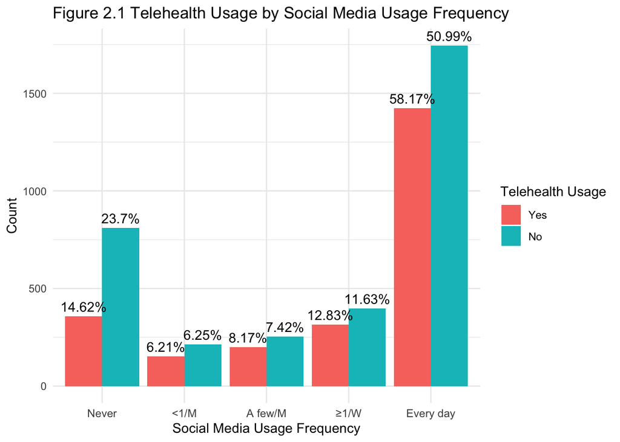

Table 2.1 Telehealth & Social Media Usage Frequency

| Telehealth | SM Usage Freqency | Count | Percentage |
| --- | --- | --- | --- |
| Yes | 1 (Never) | 358 | 14.62 |
| Yes | 2 (Less than once a month) | 152 | 6.21 |
| Yes | 3 (A few times a month) | 200 | 8.17 |
| Yes | 4 (At least once a week) | 314 | 12.83 |
| Yes | 5 (Almost every day) | 1424 | 58.17 |
| No | 1 (Never) | 811 | 23.70 |
| No | 2 (Less than once a month) | 214 | 6.25 |
| No | 3 (A few times a month) | 254 | 7.42 |
| No | 4 (At least once a week) | 398 | 11.63 |
| No | 5 (Almost every day) | 1745 | 50.99 |

Table 2.2 Telehealth & Social Media Usage Frequency

| Telehealth | 1 | 2 | 3 | 4 | 5 |
| --- | --- | --- | --- | --- | --- |
| Yes | 358 | 152 | 200 | 314 | 1424 |
| No | 811 | 214 | 254 | 398 | 1745 |

Table 2.3 Mean, Median, SD for Social Media Usage Frequency by Telehealth

| Telehealth | Mean | Median | SD | Count |
| --- | --- | --- | --- | --- |
| Yes | 3.94 | 5 | 1.49 | 2448 |
| No | 3.60 | 5 | 1.68 | 3422 |

The gap between non-users and users was particularly notable in the low group, with a higher percentage for non-users (44.68%) compared to users (31.09%). Additionally, the higher mean engagement score for users, along with the finding that the medium group had the highest percentage among users, while the low group had the highest percentage among non-users, suggests that telehealth users were more likely to engage in social media activities such as sharing, watching, and interacting than non-users.

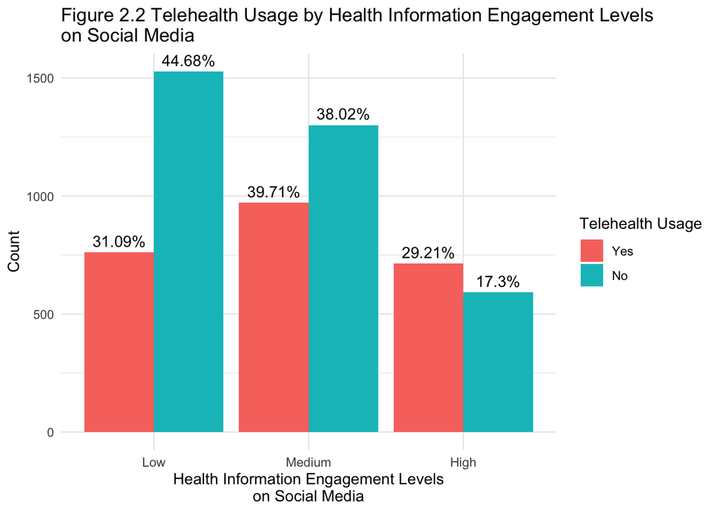

Table 2.4 Telehealth & HI SM Engagement Level

| Telehealth | HI SM Eng | Count | Percentage |
| --- | --- | --- | --- |
| Yes | Low | 761 | 31.09 |
| Yes | Medium | 972 | 39.71 |
| Yes | High | 715 | 29.21 |
| No | Low | 1529 | 44.68 |
| No | Medium | 1301 | 38.02 |
| No | High | 592 | 17.30 |

Table 2.5 Telehealth & HI SM Engagement Level

| Telehealth | Low | Medium | High |
| --- | --- | --- | --- |
| Yes | 761 | 972 | 715 |
| No | 1529 | 1301 | 592 |

Table 2.6 Mean, Median, SD for HI SM Engagement Level by Telehealth

| Telehealth | Mean | Median | SD | Count |
| --- | --- | --- | --- | --- |
| Yes | 1.63 | 1.333333 | 0.72 | 2448 |
| No | 1.42 | 1.333333 | 0.57 | 3422 |

### Cancer Risk Perception and Telehealth

Analysis revealed that regardless of cancer risk perception, there were more individuals who had not used telehealth in the past year (total = 2188) compared to those who had used it (total = 1676). Additionally, as cancer risk perception increased, the number of people who had used telehealth decreased (low = 636, medium = 551, high = 489). The gap between telehealth users and non-users was largest in the group with low cancer risk perception (user = 636, non-user = 969) and the difference narrowed as cancer risk awareness increased (medium cancer risk perception user = 551, medium cancer risk perception non-user = 701, and high cancer risk perception user = 489, high cancer risk perception non-user = 518). (See Figure 3.1 and Table 3.1)

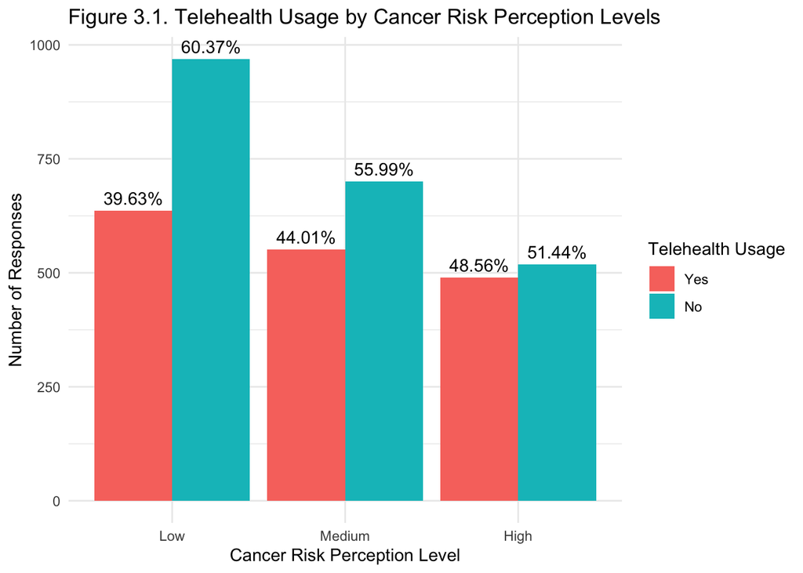

Table 3.1. Telehealth Usage by Cancer Risk Perception Levels: Distribution and Proportions

| telehealth | risk_group | count | percentage |
| --- | --- | --- | --- |
| Yes | Low | 636 | 37.95 |
| Yes | Medium | 551 | 32.88 |
| Yes | High | 489 | 29.18 |
| No | Low | 969 | 44.29 |
| No | Medium | 701 | 32.04 |
| No | High | 518 | 23.67 |

However, individuals who had used telehealth had a higher average cancer risk perception (m = 2.90, sd = 1.29) compared to those who had not used telehealth (m = 2.79, sd = 1.30). (See Table 3.2)

Table 3.2. Summary Statistics of Cancer Risk Perception by Telehealth Usage

| telehealth | riskperception_mean | riskperception_median | riskperception_sd |
| --- | --- | --- | --- |
| Yes | 2.90 | 3 | 1.29 |
| No | 2.79 | 3 | 1.30 |

## Discussion

These findings highlight the urgent need for targeted interventions to overcome demographic and systemic barriers and ensure equitable access to telehealth services for underrepresented populations. Strategies such as increasing outreach and education about the benefits of telehealth in underserved communities, alongside providing affordable and reliable access to digital tools, could significantly enhance adoption rates (Scott and Mars 2015). Furthermore, healthcare policies should prioritize aligning telehealth services with the unique needs of various demographic groups (Gallegos-Rejas et al. 2023). For individuals with lower income or education levels, the development of user-friendly platforms and the provision of personalized guidance could improve engagement and utilization (Dixit et al. 2022). Additionally, culturally sensitive approaches tailored to the preferences and needs of diverse ethnic groups are essential to fostering trust and encouraging wider acceptance of telehealth services (Willis et al. 2022).

Results for RQ2 revealed that more than half of both groups (58.17% for users, 50.99% for non-users) used social media almost daily, highlighting its prevalence regardless of telehealth usage. This suggests a need to increase exposure to telehealth-related content on social media, as repeated exposure can shape perceptions (Donaldson et al. 2022). Telehealth providers could leverage this by creating more targeted content to engage both users and non-users, potentially boosting service adoption.

The three groups (low, medium, high) for health information-related engagement levels on social media were based on relative comparison, dividing participants into upper one-third and two-thirds based on their scores. Although the engagement score of 1.67, marking the medium-high boundary, may not appear high on a 5-point Likert scale, telehealth users were most frequently in the medium group, while non-users were primarily in the low group. This suggests telehealth users engage more actively in online activities like sharing, watching, and interacting. For users, telehealth institutions could create content fostering active engagement, as seen in the ALS Ice Bucket Challenge, which inspired 17 million participants to act and donate (Phing and Yazdanifard 2014). Engaging campaigns could similarly encourage ongoing telehealth use. For non-users, strategies should prioritize awareness-building over engagement. Educational campaigns emphasizing telehealth benefits may help increase awareness and encourage future adoption.

These results suggest that although telehealth has not yet been fully widespread, future healthcare service policies may utilize telehealth as a complementary tool for face-to-face services. For people with low cancer risk perception, providing healthcare services that actively use telehealth may increase accessibility and efficiency. On the other hand, for people with high cancer concerns, a strategy that provides face-to-face services as the main method while using telehealth as a supplement may be effective. This approach may contribute to devising a plan that can meet the needs of individuals with different levels of risk perception (Young and Oppenheimer 2009) while maximizing the potential of telehealth.

In conclusion, this study underscore the need for tailored approach for the promotion of telehealth adoption that considers democgraphic factors, social media usage and engagement, and individual’s health risk perceptions. By reflecting the findings from this study, telehealth can serve as a strategical tool to supplement in-person care, improving healthcare accessibility and efficiency across diverse populations in modern health systems.

## References

Artinian, Nancy T. 2007. “Telehealth as a Tool for Enhancing Care for Patients with Cardiovascular Disease.” *Journal of Cardiovascular Nursing* 22 (1): 25–31.

Chan, Chung-hong, Thomas J. Leeper, Jason Becker, and David Schoch. 2023. *Rio: A Swiss-Army Knife for Data File i/o*. https://cran.r-project.org/package=rio.

Dixit, Niharika, Ysabella Van Sebille, Gregory B. Crawford, Pamela K. Ginex, Paz Fernandez Ortega, and Raymond J. Chan. 2022. “Disparities in Telehealth Use: How Should the Supportive Care Community Respond?” *Supportive Care in Cancer* 30 (2): 1007–10. https://doi.org/10.1007/s00520-021-06629-4.

Donaldson, Scott I, Allison Dormanesh, Cindy Perez, Anuja Majmundar, and Jon-Patrick Allem. 2022. “Association Between Exposure to Tobacco Content on Social Media and Tobacco Use: A Systematic Review and Meta-Analysis.” *JAMA Pediatrics* 176 (9): 878–85.

Gallegos-Rejas, Victor M, Emma E Thomas, Jaimon T Kelly, and Anthony C Smith. 2023. “A Multi-Stakeholder Approach Is Needed to Reduce the Digital Divide and Encourage Equitable Access to Telehealth.” *Journal of Telemedicine and Telecare* 29 (1): 73–78. https://doi.org/10.1177/1357633X221107995.

Garber, Kelli, and Tina Gustin. 2022. “Telehealth Education: Impact on Provider Experience and Adoption.” *Nurse Educator* 47 (2): 75–80.

Hatef, Elham, Renee F Wilson, Allen Zhang, Susan M Hannum, Hadi Kharrazi, Stacey A Davis, Iman Foroughmand, Jonathan P Weiner, and Karen A Robinson. 2024. “Effectiveness of Telehealth Versus in-Person Care During the COVID-19 Pandemic: A Systematic Review.” *Npj Digital Medicine* 7 (1): 157.

Moulaei, Khadijeh, Abbas Sheikhtaheri, Farhad Fatehi, Mostafa Shanbehzadeh, and Kambiz Bahaadinbeigy. 2023. “Patients’ Perspectives and Preferences Toward Telemedicine Versus in-Person Visits: A Mixed-Methods Study on 1226 Patients.” *BMC Medical Informatics and Decision Making* 23 (1): 261.

Müller, Kirill. 2020. *Here: A Simpler Way to Find Your Files*. https://CRAN.R-project.org/package=here.

National Cancer Institute. 2022. “Health Information National Trends Survey 6 (HINTS 6) Public Use Dataset.” U.S. Department of Health; Human Services, National Institutes of Health. https://hints.cancer.gov/.

———. 2024. “Overview of the HINTS 6 Survey (2022) and Data Analysis Recommendations.” U.S. Department of Health; Human Services, National Institutes of Health. https://hints.cancer.gov/.

Phing, Agnes Ng May, and Rashad Yazdanifard. 2014. “How Does ALS Ice Bucket Challenge Achieve Its Viral Outcome Through Marketing via Social Media.” *Global Journal of Management and Business Research* 14 (7): 56–63.

R Core Team. 2024. *R: A Language and Environment for Statistical Computing*. Vienna, Austria: R Foundation for Statistical Computing. https://www.R-project.org/.

Rani, Vasundhara, Abdul Hafeez-Baig, and Raj Gururajan. 2019. “Understanding Factors Influencing Adoption of Mobile Devices in Telehealth: A Quantitative Study.” In *24th Annual Conference of the Asia Pacific Decision Sciences Institute: Full Papers*. University of Southern Queensland.

Scott, Richard E, and Maurice Mars. 2015. “Telehealth in the Developing World: Current Status and Future Prospects.” *Smart Homecare Technology and TeleHealth* 3 (February): 25–37. https://doi.org/10.2147/SHTT.S75184.

Weinstein, Ronald S, Ana Maria Lopez, Bellal A Joseph, Kristine A Erps, Michael Holcomb, Gail P Barker, and Elizabeth A Krupinski. 2014. “Telemedicine, Telehealth, and Mobile Health Applications That Work: Opportunities and Barriers.” *The American Journal of Medicine* 127 (3): 183–87.

Wickham, Hadley, Mara Averick, Jennifer Bryan, Winston Chang, Lucy D’Agostino McGowan, Romain François, Garrett Grolemund, et al. 2019. “Welcome to the tidyverse.” *Journal of Open Source Software* 4 (43): 1686. https://doi.org/10.21105/joss.01686.

Willis, Henry Artez, Juan Carlos Gonzalez, Christine C. Call, David Quezada, Scholars for Elevating Equity and Diversity (SEED), and Chardée A. Galán. 2022. “Culturally Responsive Telepsychology & mHealth Interventions for Racial-Ethnic Minoritized Youth: Research Gaps and Future Directions.” *Journal of Clinical Child & Adolescent Psychology* 51 (6): 1053–69. https://doi.org/10.1080/15374416.2022.2124516.

Young, Sean, and Daniel M Oppenheimer. 2009. “Effect of Communication Strategy on Personal Risk Perception and Treatment Adherence Intentions.” *Psychology, Health & Medicine* 14 (4): 430–42.

Zhao, Yuehua, and Jin Zhang. 2017. “Consumer Health Information Seeking in Social Media: A Literature Review.” *Health Information & Libraries Journal* 34 (4): 268–83.